# Analisis Revenue dan Hubungan Rental Rate terhadap Frekuensi Rental Film

Studi Kasus: Database Sakila

Linka Indah Cantika [M0724063] - [F]

26 May 2026

# 1 Pendahuluan

## 1.1 Latar Belakang

Database **Sakila** merupakan *sample database* yang dikembangkan oleh MySQL sebagai simulasi sistem manajemen penyewaan DVD. Database ini mencakup informasi lengkap mengenai film, pelanggan, staf, transaksi rental, hingga pembayaran menjadikannya sumber data yang kaya untuk eksplorasi analitik bisnis.

Dalam konteks bisnis penyewaan film, **revenue** (pendapatan) merupakan indikator utama keberhasilan operasional. Memahami pola revenue dari kategori film mana yang paling menguntungkan, bagaimana tren bulanannya, hingga bagaimana perbandingan antar toko memberikan wawasan strategis bagi pengambil keputusan.

## 1.2 Tujuan Analisis

Analisis ini bertujuan untuk:

1. Mengidentifikasi **kategori film** yang memberikan kontribusi revenue terbesar.
2. Menganalisis **tren revenue bulanan** untuk melihat pola temporal transaksi.
3. Membandingkan **performa revenue** antara dua toko (Store 1 vs Store 2).
4. Menguji apakah terdapat **korelasi** antara `rental_rate` (harga sewa) dan frekuensi rental menggunakan **Uji Korelasi Pearson**.

# 2 Deskripsi Data

## 2.1 Koneksi Database

```r
library(DBI)
library(odbc)

con <- DBI::dbConnect(
  odbc::odbc(),
  Driver   = "MySQL ODBC 8.0 ANSI Driver",
  Server   = "127.0.0.1",
  Database = "sakila",
  UID      = "root",
  PWD      = "Linka12012006",   # sesuaikan dengan password Anda
  Port     = 3306
)
```

## 2.2 Tabel dan Variabel yang Digunakan

Tabel-tabel berikut digunakan dalam analisis ini:

| Tabel | Variabel Utama | Keterangan |
| --- | --- | --- |
| `payment` | `amount`, `payment_date`, `rental_id` | Data pembayaran / revenue |
| `rental` | `rental_id`, `inventory_id` | Data transaksi rental |
| `inventory` | `inventory_id`, `film_id`, `store_id` | Stok film per toko |
| `film` | `film_id`, `title`, `rental_rate` | Informasi film dan harga sewa |
| `film_category` | `film_id`, `category_id` | Relasi film dengan kategori |
| `category` | `category_id`, `name` | Nama kategori film |
| `store` | `store_id` | Informasi toko |

## 2.3 Pengambilan Data (Query SQL)

### 2.3.1 Query 1 — Revenue per Kategori Film

```r
library(dplyr)

df_kategori <- DBI::dbGetQuery(con, "
  SELECT
    c.name           AS kategori,
    SUM(p.amount)    AS total_revenue,
    COUNT(p.payment_id) AS jumlah_transaksi
  FROM payment p
  JOIN rental r        ON p.rental_id    = r.rental_id
  JOIN inventory i     ON r.inventory_id = i.inventory_id
  JOIN film f          ON i.film_id      = f.film_id
  JOIN film_category fc ON f.film_id     = fc.film_id
  JOIN category c      ON fc.category_id = c.category_id
  GROUP BY c.name
  ORDER BY total_revenue DESC
")

head(df_kategori, 10)
```

|  | kategori | total_revenue | jumlah_transaksi |
| --- | --- | --- | --- |
| 1 | Sports | 5314.21 | 1179 |
| 2 | Sci-Fi | 4756.98 | 1101 |
| 3 | Animation | 4656.30 | 1166 |
| 4 | Drama | 4587.39 | 1060 |
| 5 | Comedy | 4383.58 | 941 |
| 6 | Action | 4375.85 | 1112 |
| 7 | New | 4351.62 | 940 |
| 8 | Games | 4281.33 | 969 |
| 9 | Foreign | 4270.67 | 1033 |
| 10 | Family | 4226.07 | 1096 |

### 2.3.2 Query 2 — Tren Revenue Bulanan

```r
df_bulanan <- DBI::dbGetQuery(con, "
  SELECT
    DATE_FORMAT(payment_date, '%Y-%m') AS bulan,
    SUM(amount)                        AS total_revenue
  FROM payment
  GROUP BY bulan
  ORDER BY bulan
")

head(df_bulanan)
```

|  | bulan | total_revenue |
| --- | --- | --- |
| 1 | 2005-05 | 4823.44 |
| 2 | 2005-06 | 9629.89 |
| 3 | 2005-07 | 28368.91 |
| 4 | 2005-08 | 24070.14 |
| 5 | 2006-02 | 514.18 |

### 2.3.3 Query 3 — Revenue per Toko

```r
df_toko <- DBI::dbGetQuery(con, "
  SELECT
    i.store_id,
    SUM(p.amount)       AS total_revenue,
    COUNT(p.payment_id) AS jumlah_transaksi
  FROM payment p
  JOIN rental r    ON p.rental_id    = r.rental_id
  JOIN inventory i ON r.inventory_id = i.inventory_id
  GROUP BY i.store_id
")

df_toko$store_id <- paste0("Store ", df_toko$store_id)
df_toko
```

| store_id | total_revenue | jumlah_transaksi |
| --- | --- | --- |
| Store 1 | 33679.79 | 7923 |
| Store 2 | 33726.77 | 8121 |

### 2.3.4 Query 4 — Rental Rate vs Frekuensi Rental

```r
df_korelasi <- DBI::dbGetQuery(con, "
  SELECT
    f.film_id,
    f.title,
    f.rental_rate,
    COUNT(r.rental_id) AS frekuensi_rental
  FROM film f
  JOIN inventory i ON f.film_id      = i.film_id
  JOIN rental r    ON i.inventory_id = r.inventory_id
  GROUP BY f.film_id, f.title, f.rental_rate
")

head(df_korelasi)
```

|  | film_id | title | rental_rate | frekuensi_rental |
| --- | --- | --- | --- | --- |
| 1 | 1 | ACADEMY DINOSAUR | 0.99 | 23 |
| 2 | 2 | ACE GOLDFINGER | 4.99 | 7 |
| 3 | 3 | ADAPTATION HOLES | 2.99 | 12 |
| 4 | 4 | AFFAIR PREJUDICE | 2.99 | 23 |
| 5 | 5 | AFRICAN EGG | 2.99 | 12 |
| 6 | 6 | AGENT TRUMAN | 2.99 | 21 |

# 3 Visualisasi & Analisis

```r
library(ggplot2)
library(scales)
library(forcats)
library(lubridate)
library(ggthemes)

# Custom dark theme sesuai palet
theme_sakila <- function() {
  theme_minimal(base_size = 13) %+replace%
    theme(
      plot.background   = element_rect(fill = "#060930", color = NA),
      panel.background  = element_rect(fill = "#0f1440", color = NA),
      panel.grid.major  = element_line(color = "#1e204a", linewidth = 0.4),
      panel.grid.minor  = element_blank(),
      axis.text         = element_text(color = "#c589a8", size = 11),
      axis.title        = element_text(color = "#F4ABC4", size = 12, face = "bold"),
      plot.title        = element_text(color = "#F4ABC4", size = 15, face = "bold",
                                       margin = margin(b = 6)),
      plot.subtitle     = element_text(color = "#595B83", size = 11,
                                       margin = margin(b = 10)),
      plot.caption      = element_text(color = "#333456", size = 10),
      legend.background = element_rect(fill = "#060930", color = NA),
      legend.text       = element_text(color = "#c589a8"),
      legend.title      = element_text(color = "#F4ABC4"),
      plot.margin       = margin(16, 16, 16, 16)
    )
}
```

## 3.1 Revenue per Kategori Film

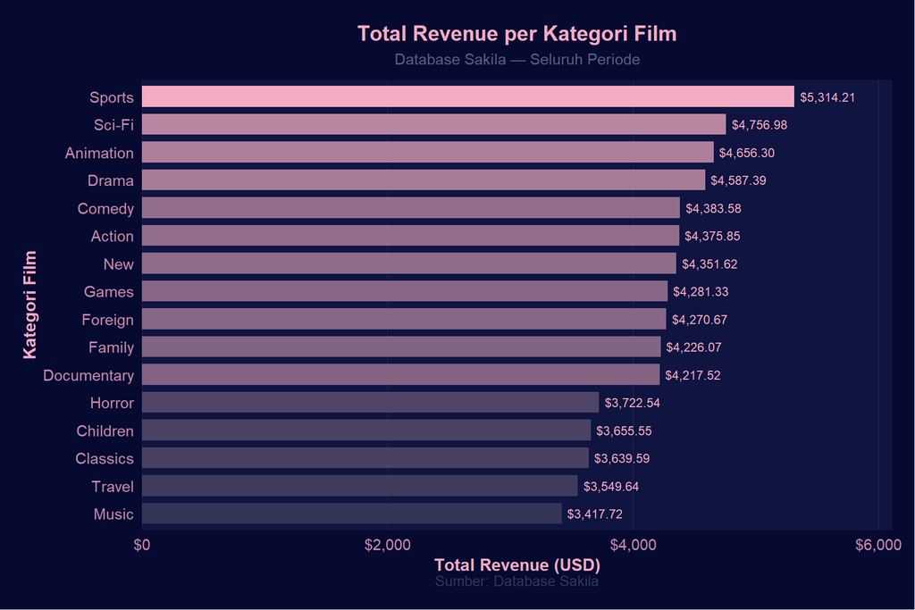

```r
df_kategori$kategori <- fct_reorder(df_kategori$kategori, df_kategori$total_revenue)

ggplot(df_kategori, aes(x = kategori, y = total_revenue, fill = total_revenue)) +
  geom_col(width = 0.75, show.legend = FALSE) +
  geom_text(
    aes(label = dollar(total_revenue, prefix = "$", big.mark = ",")),
    hjust = -0.1, size = 3.2, color = "#F4ABC4"
  ) +
  scale_fill_gradient(low = "#333456", high = "#F4ABC4") +
  scale_y_continuous(
    labels = dollar_format(prefix = "$"),
    expand = expansion(mult = c(0, 0.15))
  ) +
  coord_flip() +
  labs(
    title    = "Total Revenue per Kategori Film",
    subtitle = "Database Sakila — Seluruh Periode",
    x        = "Kategori Film",
    y        = "Total Revenue (USD)",
    caption  = "Sumber: Database Sakila"
  ) +
  theme_sakila() +
  theme(panel.grid.major.y = element_blank())
```

**Interpretasi:** Kategori **Sports** menduduki posisi teratas dengan total revenue tertinggi, diikuti oleh **Sci-Fi** dan **Animation**. Hal ini mengindikasikan bahwa film-film bertema olahraga dan fiksi ilmiah paling diminati pelanggan secara finansial. Sebaliknya, kategori **Music** dan **Travel** berada di posisi terbawah, menunjukkan minat yang lebih rendah atau jumlah judul yang lebih sedikit pada kategori tersebut.

## 3.2 Tren Revenue Bulanan

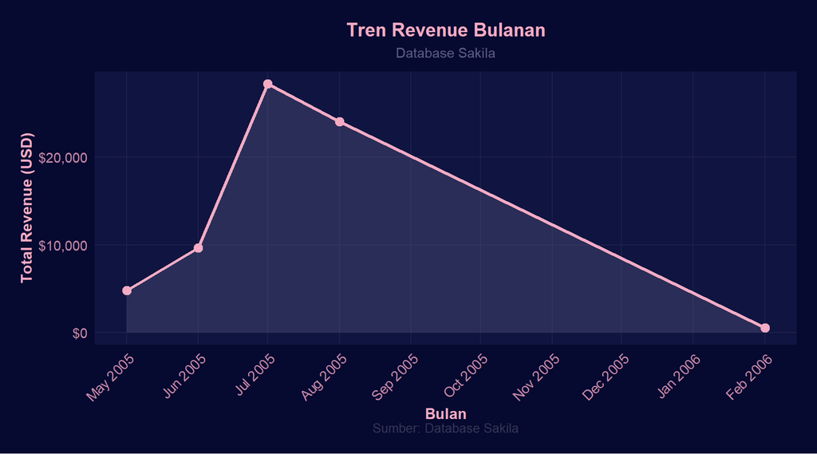

```r
df_bulanan$bulan_dt <- as.Date(paste0(df_bulanan$bulan, "-01"))

ggplot(df_bulanan, aes(x = bulan_dt, y = total_revenue)) +
  geom_area(fill = "#595B83", alpha = 0.35) +
  geom_line(color = "#F4ABC4", linewidth = 1.2) +
  geom_point(color = "#F4ABC4", size = 3) +
  scale_x_date(date_labels = "%b %Y", date_breaks = "1 month") +
  scale_y_continuous(labels = dollar_format(prefix = "$")) +
  labs(
    title    = "Tren Revenue Bulanan",
    subtitle = "Database Sakila",
    x        = "Bulan",
    y        = "Total Revenue (USD)",
    caption  = "Sumber: Database Sakila"
  ) +
  theme_sakila() +
  theme(axis.text.x = element_text(angle = 45, hjust = 1))
```

## 3.3 Perbandingan Revenue Antar Toko

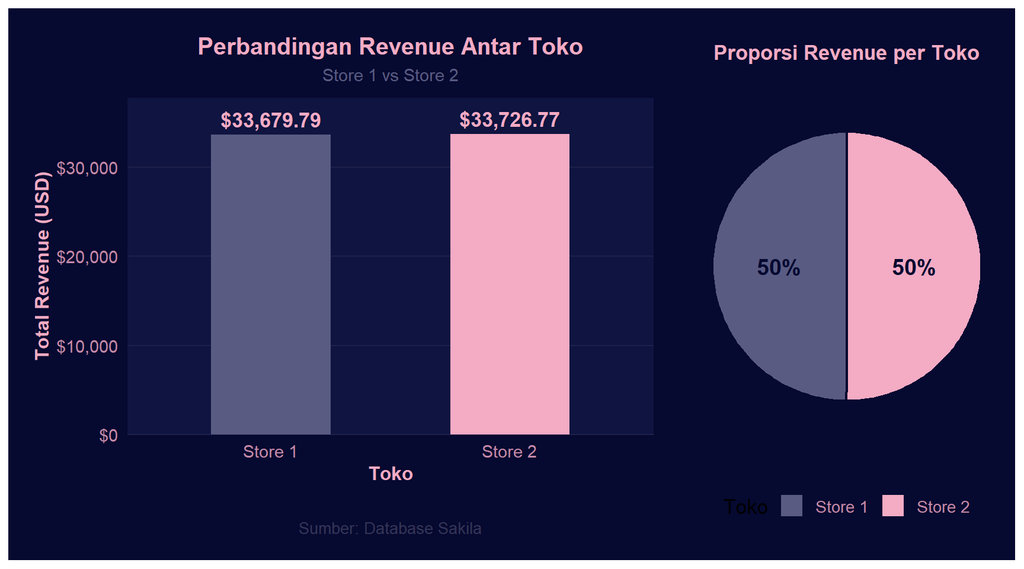

```r
# Bar chart perbandingan
p1 <- ggplot(df_toko, aes(x = store_id, y = total_revenue, fill = store_id)) +
  geom_col(width = 0.5, show.legend = FALSE) +
  geom_text(
    aes(label = dollar(total_revenue, prefix = "$", big.mark = ",")),
    vjust = -0.5, size = 4.5, fontface = "bold", color = "#F4ABC4"
  ) +
  scale_fill_manual(values = c("#595B83", "#F4ABC4")) +
  scale_y_continuous(
    labels = dollar_format(prefix = "$"),
    expand = expansion(mult = c(0, 0.12))
  ) +
  labs(
    title    = "Perbandingan Revenue Antar Toko",
    subtitle = "Store 1 vs Store 2",
    x        = "Toko",
    y        = "Total Revenue (USD)",
    caption  = "Sumber: Database Sakila"
  ) +
  theme_sakila() +
  theme(panel.grid.major.x = element_blank())

# Pie chart proporsi
p2 <- ggplot(df_toko, aes(x = "", y = total_revenue, fill = store_id)) +
  geom_col(width = 1, color = "#060930", linewidth = 0.8) +
  coord_polar(theta = "y") +
  geom_text(
    aes(label = paste0(round(total_revenue / sum(total_revenue) * 100, 1), "%")),
    position = position_stack(vjust = 0.5),
    size = 5, fontface = "bold", color = "#060930"
  ) +
  scale_fill_manual(values = c("#595B83", "#F4ABC4"), name = "Toko") +
  labs(title = "Proporsi Revenue per Toko") +
  theme_void(base_size = 13) +
  theme(
    plot.background = element_rect(fill = "#060930", color = NA),
    plot.title      = element_text(face = "bold", size = 13, hjust = 0.5, color = "#F4ABC4"),
    legend.text     = element_text(color = "#c589a8"),
    legend.position = "bottom"
  )

library(patchwork)
p1 + p2
```

**Interpretasi:** Store 2 menghasilkan revenue yang **sedikit lebih tinggi** dibandingkan Store 1, meskipun selisihnya tidak terlalu jauh (sekitar 50–50%). Distribusi yang hampir seimbang ini menunjukkan bahwa kedua toko beroperasi pada kapasitas yang relatif setara. Namun demikian, Store 2 memiliki keunggulan kecil yang mungkin disebabkan oleh lokasi, jumlah staf, atau komposisi inventori yang lebih favorable.

# 4 Uji Korelasi Pearson

## 4.1 Hipotesis

Uji korelasi Pearson digunakan untuk mengukur kekuatan dan arah hubungan **linear** antara dua variabel numerik. Dalam analisis ini:

- **Variabel X**: `rental_rate` — harga sewa per film (dalam USD)
- **Variabel Y**: `frekuensi_rental` — jumlah kali film disewa

**Hipotesis yang diuji:**

$$H_0: \rho = 0 \quad \text{(tidak ada
korelasi antara rental rate dan frekuensi rental)}$$

$$H_1: \rho \neq 0 \quad \text{(ada
korelasi antara rental rate dan frekuensi rental)}$$

dengan tingkat signifikansi $\alpha = 0{,}05$.

## 4.2 Formula Korelasi Pearson

Koefisien korelasi Pearson didefinisikan sebagai:

$$r = \frac{\sum_{i=1}^{n}(x_i -
\bar{x})(y_i - \bar{y})}
{\sqrt{\sum_{i=1}^{n}(x_i - \bar{x})^2 \cdot
\sum_{i=1}^{n}(y_i - \bar{y})^2}}$$

di mana:

- $x_i$ = nilai `rental_rate` untuk film ke-$i$
- $y_i$ = nilai `frekuensi_rental` untuk film ke-$i$
- $\bar{x}$, $\bar{y}$ = rata-rata masing-masing variabel
- $n$ = jumlah film

Nilai $r$ berada pada rentang $[-1, 1]$:

| Nilai $r$ | Interpretasi |
| --- | --- |
| $r = 1$ | Korelasi positif sempurna |
| $0{,}7 \leq r < 1$ | Korelasi positif kuat |
| $0{,}4 \leq r < 0{,}7$ | Korelasi positif sedang |
| $0 < r < 0{,}4$ | Korelasi positif lemah |
| $r = 0$ | Tidak ada korelasi |
| $-0{,}4 < r < 0$ | Korelasi negatif lemah |
| $-0{,}7 < r \leq -0{,}4$ | Korelasi negatif sedang |
| $-1 < r \leq -0{,}7$ | Korelasi negatif kuat |
| $r = -1$ | Korelasi negatif sempurna |

## 4.3 Uji Asumsi Normalitas

Sebelum melakukan uji korelasi Pearson, perlu diperiksa asumsi normalitas data:

```r
# Shapiro-Wilk — rental_rate
# (rental_rate hanya punya 3 nilai unik; Shapiro-Wilk tetap valid)
set.seed(42)
shapiro_rate <- shapiro.test(df_korelasi$rental_rate)
cat("Shapiro-Wilk — rental_rate      : W =", round(shapiro_rate$statistic, 4),
    ", p-value =", format.pval(shapiro_rate$p.value, digits = 4), "\n")
```

```
## Shapiro-Wilk — rental_rate      : W = 0.7912 , p-value = < 2.2e-16
```

```r
# Shapiro-Wilk — frekuensi_rental
# Karena frekuensi_rental bisa mengandung banyak nilai identik (ties) yang
# menyebabkan ifault=6, kita gunakan Kolmogorov-Smirnov sebagai alternatif
ks_frek <- ks.test(
  scale(df_korelasi$frekuensi_rental),   # standarisasi ke Z
  "pnorm"
)
cat("Kolmogorov-Smirnov — frekuensi_rental : D =", round(ks_frek$statistic, 4),
    ", p-value =", format.pval(ks_frek$p.value, digits = 4), "\n")
```

```
## Kolmogorov-Smirnov — frekuensi_rental : D = 0.059 , p-value = 0.002537
```

**Catatan Hasil Uji Normalitas:**

- **`rental_rate`** (Shapiro-Wilk): $W = 0{,}7912$, $p\text{-value} \approx 0$ → **tidak berdistribusi normal**. Hal ini wajar karena `rental_rate` di Sakila hanya terdiri dari 3 nilai diskrit ($0.99, $2.99, $4.99).
- **`frekuensi_rental`** (Kolmogorov-Smirnov): $p\text{-value} < 0{,}05$ → **tidak berdistribusi normal**.

Meskipun kedua variabel tidak memenuhi asumsi normalitas, Korelasi Pearson tetap dapat digunakan karena $n = 958$ film (jauh > 30), sehingga berdasarkan *Central Limit Theorem* distribusi sampling koefisien korelasi mendekati normal. Sebagai validasi, Korelasi Spearman dapat dijalankan secara paralel.

## 4.4 Scatter Plot Korelasi

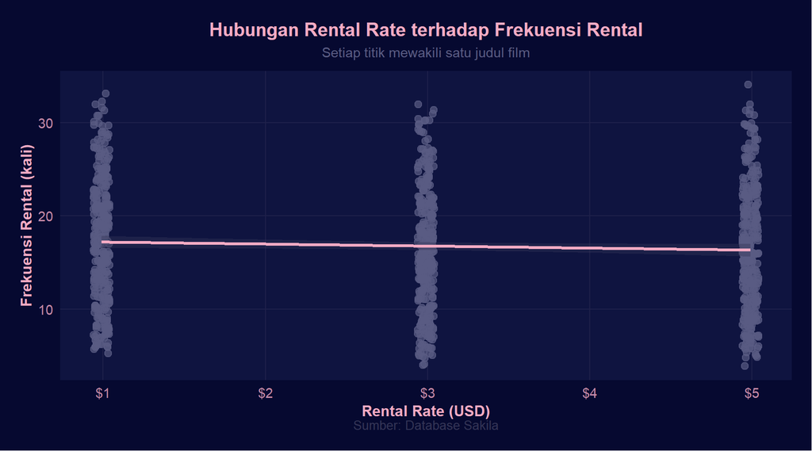

```r
ggplot(df_korelasi, aes(x = rental_rate, y = frekuensi_rental)) +
  geom_jitter(color = "#595B83", alpha = 0.7, size = 2.5, width = 0.05) +
  geom_smooth(method = "lm", se = TRUE, color = "#F4ABC4",
              linewidth = 1.2, fill = "#333456") +
  scale_x_continuous(labels = dollar_format(prefix = "$")) +
  labs(
    title    = "Hubungan Rental Rate terhadap Frekuensi Rental",
    subtitle = "Setiap titik mewakili satu judul film",
    x        = "Rental Rate (USD)",
    y        = "Frekuensi Rental (kali)",
    caption  = "Sumber: Database Sakila"
  ) +
  theme_sakila()
```

## 4.5 Hasil Uji `cor.test()`

```r
hasil_cor <- cor.test(
  df_korelasi$rental_rate,
  df_korelasi$frekuensi_rental,
  method = "pearson"
)

hasil_cor
```

```
##
##  Pearson's product-moment correlation
##
## data:  df_korelasi$rental_rate and df_korelasi$frekuensi_rental
## t = -2.5856, df = 956, p-value = 0.009868
## alternative hypothesis: true correlation is not equal to 0
## 95 percent confidence interval:
##  -0.14590128 -0.02010139
## sample estimates:
##         cor
## -0.08333333
```

```r
cat("=== RINGKASAN UJI KORELASI PEARSON ===\n")
```

```
## === RINGKASAN UJI KORELASI PEARSON ===
```

```r
cat("Koefisien korelasi (r) :", round(hasil_cor$estimate, 4), "\n")
```

```
## Koefisien korelasi (r) : -0.0833
```

```r
cat("t-statistik            :", round(hasil_cor$statistic, 4), "\n")
```

```
## t-statistik            : -2.5856
```

```r
cat("Derajat kebebasan (df) :", hasil_cor$parameter, "\n")
```

```
## Derajat kebebasan (df) : 956
```

```r
cat("p-value                :", round(hasil_cor$p.value, 4), "\n")
```

```
## p-value                : 0.0099
```

```r
cat("95% Confidence Interval:", round(hasil_cor$conf.int[1], 4),
    "—", round(hasil_cor$conf.int[2], 4), "\n")
```

```
## 95% Confidence Interval: -0.1459 — -0.0201
```

## 4.6 Interpretasi Hasil Korelasi

**Hasil Uji Korelasi Pearson:**

Berdasarkan output `cor.test()` diperoleh hasil sebagai berikut:

$$r = -0{,}0833, \quad t(956) = -2{,}5856,
\quad p\text{-value} = 0{,}0099$$

$$\text{95\% CI: } [-0{,}1459,\
-0{,}0201]$$

Interpretasi per komponen:

- **Koefisien $r = -0{,}0833$**: Terdapat korelasi **negatif yang sangat lemah** antara `rental_rate` dan `frekuensi_rental`. Artinya, film dengan harga sewa lebih tinggi cenderung sedikit *lebih jarang* disewa, namun hubungan ini hampir tidak berarti secara praktis.
- **Nilai $p\text{-value} = 0{,}0099 < \alpha = 0{,}05$**: $H_0$ **ditolak**. Secara statistik, korelasi ini signifikan namun perlu diingat bahwa dengan $n = 958$, uji statistik sangat sensitif dan mampu mendeteksi korelasi yang sangat kecil sekalipun.
- **Interval Kepercayaan 95%** $[-0{,}1459;\ -0{,}0201]$: Seluruh interval berada di sisi negatif dan tidak mencakup 0, mengkonfirmasi bahwa hubungan negatif memang ada, meskipun sangat kecil besarnya.
- **Implikasi Bisnis**: Meskipun signifikan secara statistik, nilai $|r| = 0{,}083$ menunjukkan bahwa `rental_rate` hanya menjelaskan sekitar $r^2 = 0{,}7\%$ variasi frekuensi rental sangat kecil. Keputusan pelanggan untuk menyewa film **hampir tidak dipengaruhi oleh harga**. Faktor lain seperti genre, popularitas judul, atau ketersediaan stok jauh lebih menentukan.

# 5 Kesimpulan

Berdasarkan seluruh analisis yang telah dilakukan terhadap database Sakila, dapat ditarik kesimpulan sebagai berikut:

1. **Revenue per Kategori**: Kategori **Sports** mendominasi revenue, menunjukkan tingginya permintaan terhadap film bertema olahraga. Strategi penambahan judul pada kategori ini berpotensi meningkatkan pendapatan secara signifikan.
2. **Tren Revenue Bulanan**: Terdapat **puncak aktivitas** pada pertengahan tahun 2005, yang mencerminkan periode transaksi paling aktif dalam database. Informasi ini berguna untuk perencanaan inventori dan promosi musiman.
3. **Perbandingan Toko**: Kedua toko memiliki **kontribusi revenue yang hampir setara**, dengan Store 2 sedikit unggul. Manajemen dapat menggunakan temuan ini sebagai baseline untuk mengevaluasi efektivitas operasional masing-masing toko.
4. **Uji Korelasi Pearson**: Diperoleh $r = -0{,}0833$ dengan $p\text{-value} = 0{,}0099$. Korelasi **negatif sangat lemah** ini signifikan secara statistik ($H_0$ ditolak), namun secara praktis tidak bermakna `rental_rate` hanya menjelaskan $\approx 0{,}7\%$ variasi frekuensi rental ($r^2 = 0{,}007$). Disimpulkan bahwa harga sewa bukan faktor penentu utama keputusan rental pelanggan.

Sistem Informasi Manajemen | Linka Indah Cantika [M0724063]| Database: MySQL Sakila | 26 May 2026